# Analyzing WeRateDogs

[figure not shown]

WeRateDogs is a Twitter account that rates people's dogs with a humorous comment about the dog. These ratings almost always have a denominator of 10. The numerators, though? Almost always greater than 10. 11/10, 12/10, 13/10, etc. Why? Because "they're good dogs Brent." WeRateDogs has over 4 million followers and has received international media coverage. After, we gathered, assessed, and cleaned our datasets, here are the following analysis and visualizations.

```python
# import all packages and set plots to be embedded inline
import numpy as np
import pandas as pd
import matplotlib.pyplot as plt
import seaborn as sns

%matplotlib inline
```

```python
# load in the dataset into pandas dataframe
df = pd.read_csv('twitter_archive_master.csv')
#df_master_arch3.to_csv('twitter_archive_master.csv', index=False)
```

```python
# Overview of our clean DataFrame info and composition
df.info()
```

```
<class 'pandas.core.frame.DataFrame'>
RangeIndex: 2054 entries, 0 to 2053
Data columns (total 20 columns):
tweet_id          2054 non-null int64
favorite_count    2054 non-null int64
retweet_count     2054 non-null int64
p1                2054 non-null object
p1_conf           2054 non-null float64
p1_dog            2054 non-null bool
p2                2054 non-null object
p2_conf           2054 non-null float64
p2_dog            2054 non-null bool
p3                2054 non-null object
p3_conf           2054 non-null float64
p3_dog            2054 non-null bool
rating            2054 non-null float64
stage             2054 non-null object
Date              2054 non-null object
Year              2054 non-null int64
Month             2054 non-null object
Day_of_Week       2054 non-null object
Time              2054 non-null object
Hour              2054 non-null int64
dtypes: bool(3), float64(4), int64(5), object(8)
memory usage: 278.9+ KB
```

### Favorite count versus Retweet count

[figure not shown]

```python
plt.figure(1, figsize = (8, 5))
plt.plot(df.favorite_count, df.retweet_count, marker='o', linestyle='', ms=2 )
plt.title('Favorite Count vs Retweet Count)'
plt.xscale('log')
plt.ylabel('Favorite Count')
plt.yscale('log')
plt.xlabel('Retweet Count')
plt.show();
```

We have a strong correlation between favorite and retweet count. This is not suprising. Anybody who has a twitter account could tell you how both numbers increase or decrease at the same time.

### what type of dog stage has highest rating?

```python
# define the average dog stage by rating
df1 = df.groupby(['stage'])['rating'].mean()
df1
```

```
stage
Unidentified    1.049714
doggo           1.197015
doggofloofer    1.100000
doggopupper     1.118182
doggopuppo      1.300000
floofer         1.200000
pupper          1.067464
puppo           1.200000
Name: rating, dtype: float64
```

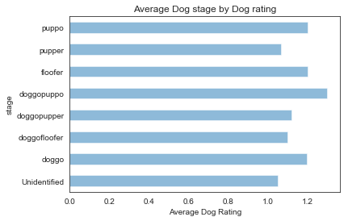

```python
# plot
df1 = df.groupby(['stage'])['rating'].mean()
df1.plot(kind ='barh', align='center', alpha=0.5)
plt.xlabel('Average Dog Rating')
plt.title('Average Dog stage by Dog rating')
plt.show();
```

### what type of dog stage has highest favorite count?

```python
# define the average dog stage by rating
df2 = df.groupby(['stage'])['favorite_count'].mean()
df2
```

```
stage
Unidentified     8194.895101
doggo           18200.776119
doggofloofer    17169.000000
doggopupper     10254.363636
doggopuppo      47844.000000
floofer         13206.000000
pupper           6956.081340
puppo           20643.739130
Name: favorite_count, dtype: float64
```

[figure not shown]

```python
# plot
df2 = df.groupby(['stage'])['rating'].mean()
df2.plot(kind ='barh', align='center', alpha=0.5)
plt.xlabel('Average Dog Favorite count')
plt.title('Average Dog stage by favorite count ')
plt.show()
```

### what is the tweet id puppo who's has the highest favorite count?

```python
df.loc[df['favorite_count'].idxmax()]
```

```
tweet_id          822872901745569793
favorite_count                132810
retweet_count                  48265
p1                  Lakeland_Terrier
p1_conf                     0.196015
p1_dog                          True
p2                Labrador_Retriever
p2_conf                     0.160329
p2_dog                          True
p3                     Irish_Terrier
p3_conf                    0.0691262
p3_dog                          True
rating                           1.3
stage                          puppo
Date                      2017-01-21
Year                            2017
Month                        January
Day_of_Week                 Saturday
Time                        18:26:02
Hour                              18
Name: 329, dtype: object
```

The puppo who's has the maximum favorite value is 132810

### Overall, how many original tweets were posted per month?

```python
tweets_per_month = df.groupby(['Month', 'Year'],
                               sort=False).count().iloc[::-1, 0]
```

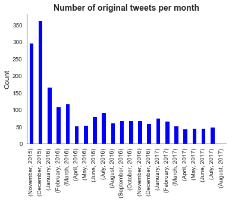

```python
fig, ax = plt.subplots()
sns.set_style("white")
tweets_per_month.plot(kind='bar', color='b')
ax.set_title('Number of original tweets per month', fontsize=14, fontweight="bold")
ax.set_ylabel('Count', fontsize=12)
ax.set_xlabel('')
ax.spines['right'].set_visible(False)
ax.spines['top'].set_visible(False)
```

November and December of 2015 were the most busy months for WeRateDogs twitter account with the number of original posted tweets exceeding 250 and 350 respectively. From April 2016 and onwards no month had more than 100 tweets posted. This make sense because during these two months, we have Thanksgiving, chrismas and New Year's Eve holidays. A lot of people are on vacantion and spend more time with family and friends. So, reason why they have time to catch up with friens and family.